# TUGAS PERTEMUAN 4

# MA(2)

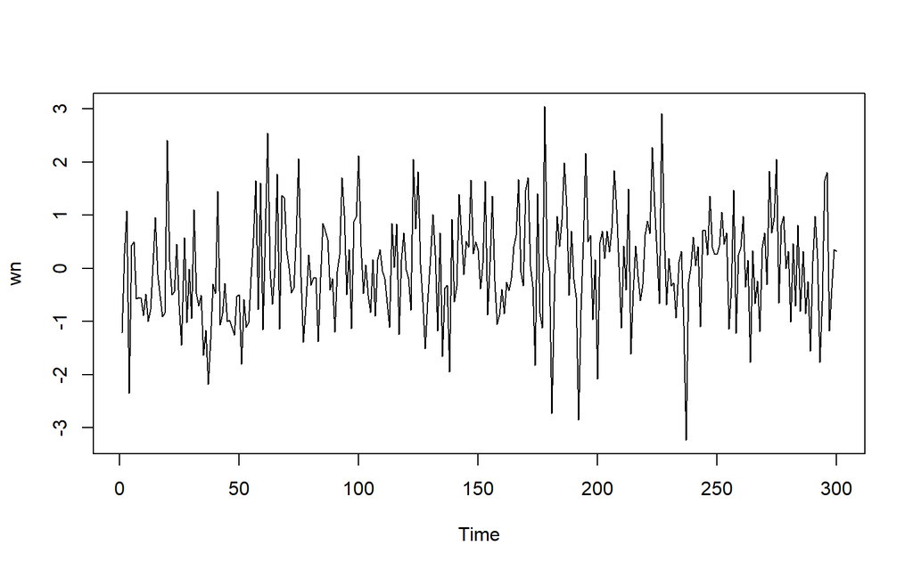

```r
set.seed(1234)
wn <- rnorm(300)
ts.plot(wn)
```

Dapat terlihat bahwa *white noise* tidak memiliki autokorelasi dari ACF. Perhatikan bahwa lag ke-0 adalah korelasi observasi ke-t dengan dirinya sendiri. Nilai korelasi tersebut pasti 1. Sebagai alternatif, lag pertama di plot ACF dapat ditetapkan sebagai 1 (alih-alih 0) dengan menambahkan argumen `xlim(1, lag akhir)`. Plot tersebut dapat disandingkan bersamaan dengan membuat matriks $1 \times 2$ dengan `par(mfrow = c(1,2))`.

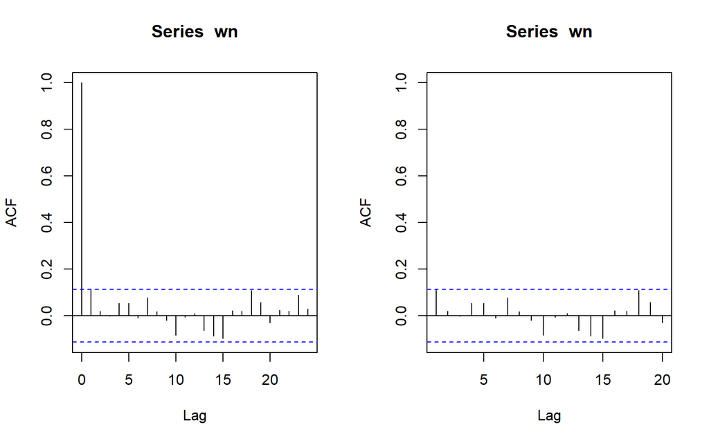

```r
par(mfrow = c(1, 2))
acf(wn)
acf(wn, xlim = c(1, 20))
```

## Proses MA

Proses MA dapat dituliskan sebagai berikut:

$$y_{t} = c + e_t + \theta_{1}e_{t-1} + \theta_{2}e_{t-2} + \dots +
\theta_{q}e_{t-q} = c+{e_t+\sum_{i=1}^p \theta_ie_{t-i}}$$
Terlihat bahwa $e_t$, atau *white noise*, berperan penting dalam pembangkitan proses MA.

## Pembangkitan Proses MA(2)

```r
set.seed(1234)
ma <- wn[1:2]
```

$$y_t = e_t+0.4e_{t-1}+0.6e_{t-2}$$

```r
for(i in 3:300){
   ma[i] <- wn[i] + 0.4 * wn[i - 1] + 0.6 * wn[i - 2]
}
ma
```

```
##   [1] -1.207065749  0.277429242  0.471173424 -1.745463687  0.141510314
##   [6] -0.729712854 -0.114842790 -0.472894305 -1.127948717 -1.443797742
##  [11] -1.171879031 -1.723286222 -1.461924092 -0.845074607  0.519525249
##  [16]  0.312187420  0.020572732 -1.181770516 -1.508255550  1.534249256
##  [21]  0.598119283  1.012450498 -0.556369299 -0.011041246 -0.774213194
##  [26] -1.449939345 -0.420758391 -1.662676381 -0.079747157 -1.556197355
##  [31]  0.718835126 -0.596243221 -0.238298741 -1.070389923 -2.255260716
##  [36] -2.120011486 -3.624543435 -2.913580609 -2.138714925 -1.388210999
##  [41]  1.086560934 -0.768382742 -0.413123964 -1.263954490 -1.619808057
##  [46] -1.534624150 -2.091327966 -2.276021753 -1.689013389 -1.457572736
##  [51] -2.319068111 -1.602598402 -2.425338748 -1.807763414 -1.233628102
##  [56] -0.110845196  1.775654086  0.223607057  2.285258743 -0.979456751
##  [61]  1.157010823  2.116941328  1.378789117  0.845856907 -0.296314421
##  [66]  1.372262398 -0.432336811  1.978634754  1.193531021  1.688995021
##  [71]  0.939220832 -0.250827924 -0.544575725  0.228395751  2.109671129
```

[output cut: 45 more lines]

Selain menggunakan cara di atas, pembangkitan proses MA(2) dapat dilakukan dengan fungsi `arima.sim()` sebagai berikut.

```r
ma2 <- arima.sim(list(order=c(0,0,2), ma=c(0.4 , 0.6)), n=300)
ma2
```

[output not shown]

[output cut: 49 more lines]

## Karakteristik MA(2)

### Plot Time Series

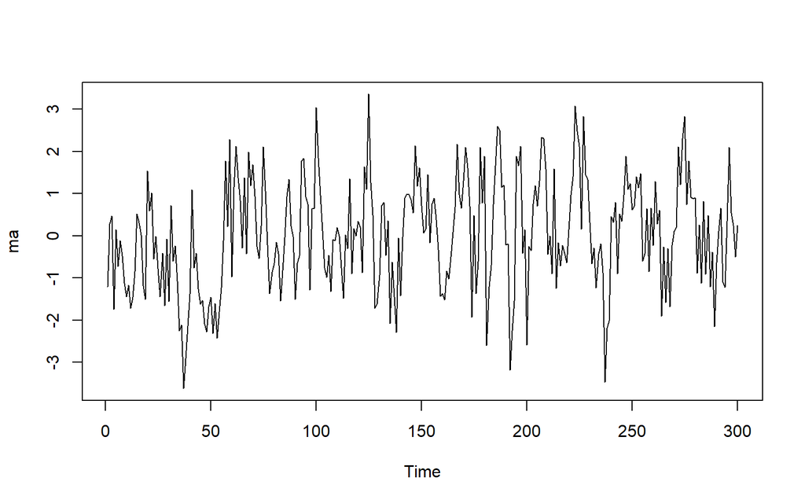

```r
ts.plot(ma)
```

Berdasarkan plot time series, terlihat bahwa data MA(2) yang dibangkitkan stasioner dalam rataan

### Plot ACF

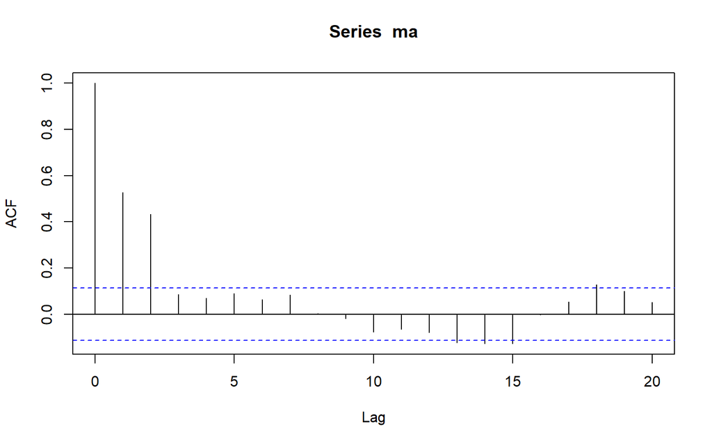

```r
acf(ma,lag.max = 20)
```

Berdasarkan plot AFC tersebut, terlihat bahwa plot ACF *cuts off* di lag kedua

### Plot PACF

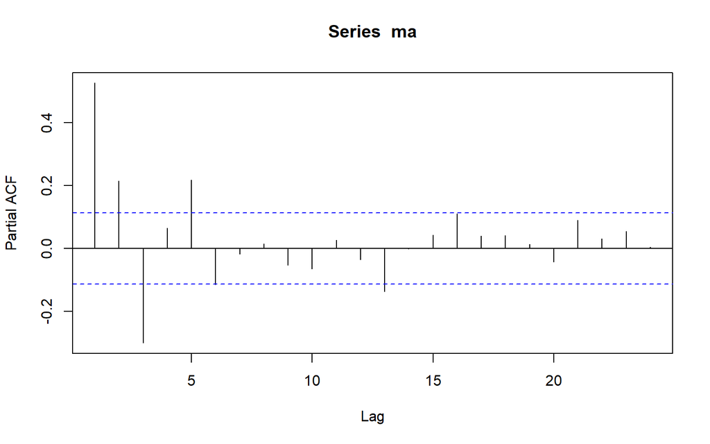

```r
pacf(ma)
```

Berdasarkan plot PACF tersebut, terlihat bahwa plot PACF cenderung *tails off* dan membentuk gelombang sinus

### Plot EACF

```r
TSA::eacf(ma)
```

```
## AR/MA
##   0 1 2 3 4 5 6 7 8 9 10 11 12 13
## 0 x x o o o o o o o o o  o  x  x
## 1 x x x o o o o o o o o  o  o  o
## 2 x x x x o o o o o o o  o  o  o
## 3 x x x x x o o o o o o  o  o  o
## 4 x x x x x o o o o o o  o  o  o
## 5 x x x x x o x o o o o  o  o  o
## 6 x x x o x o o x o o o  o  o  o
## 7 x o x o x o o x o o o  o  o  o
```

Berdasarkan pola segitiga nol pada plot EACF, terlihat bahwa segitiga nol berada pada ordo AR(0) dan ordo MA(2)

### Scatterplot Antar Lag

#### Korelasi antara $Y_t$ dengan $Y_{t-1}$

```r
#Yt
yt_ma <- ma[-1]
yt_ma
```

```
##   [1]  0.277429242  0.471173424 -1.745463687  0.141510314 -0.729712854
##   [6] -0.114842790 -0.472894305 -1.127948717 -1.443797742 -1.171879031
##  [11] -1.723286222 -1.461924092 -0.845074607  0.519525249  0.312187420
##  [16]  0.020572732 -1.181770516 -1.508255550  1.534249256  0.598119283
##  [21]  1.012450498 -0.556369299 -0.011041246 -0.774213194 -1.449939345
##  [26] -0.420758391 -1.662676381 -0.079747157 -1.556197355  0.718835126
##  [31] -0.596243221 -0.238298741 -1.070389923 -2.255260716 -2.120011486
##  [36] -3.624543435 -2.913580609 -2.138714925 -1.388210999  1.086560934
##  [41] -0.768382742 -0.413123964 -1.263954490 -1.619808057 -1.534624150
##  [46] -2.091327966 -2.276021753 -1.689013389 -1.457572736 -2.319068111
##  [51] -1.602598402 -2.425338748 -1.807763414 -1.233628102 -0.110845196
##  [56]  1.775654086  0.223607057  2.285258743 -0.979456751  1.157010823
##  [61]  2.116941328  1.378789117  0.845856907 -0.296314421  1.372262398
##  [66] -0.432336811  1.978634754  1.193531021  1.688995021  0.939220832
##  [71] -0.250827924 -0.544575725  0.228395751  2.109671129  1.063681873
```

[output cut: 45 more lines]

```r
#Yt-1
yt_1_ma <- ma[-300]
yt_1_ma
```

```
##   [1] -1.207065749  0.277429242  0.471173424 -1.745463687  0.141510314
##   [6] -0.729712854 -0.114842790 -0.472894305 -1.127948717 -1.443797742
##  [11] -1.171879031 -1.723286222 -1.461924092 -0.845074607  0.519525249
##  [16]  0.312187420  0.020572732 -1.181770516 -1.508255550  1.534249256
##  [21]  0.598119283  1.012450498 -0.556369299 -0.011041246 -0.774213194
##  [26] -1.449939345 -0.420758391 -1.662676381 -0.079747157 -1.556197355
##  [31]  0.718835126 -0.596243221 -0.238298741 -1.070389923 -2.255260716
##  [36] -2.120011486 -3.624543435 -2.913580609 -2.138714925 -1.388210999
##  [41]  1.086560934 -0.768382742 -0.413123964 -1.263954490 -1.619808057
##  [46] -1.534624150 -2.091327966 -2.276021753 -1.689013389 -1.457572736
##  [51] -2.319068111 -1.602598402 -2.425338748 -1.807763414 -1.233628102
##  [56] -0.110845196  1.775654086  0.223607057  2.285258743 -0.979456751
##  [61]  1.157010823  2.116941328  1.378789117  0.845856907 -0.296314421
##  [66]  1.372262398 -0.432336811  1.978634754  1.193531021  1.688995021
##  [71]  0.939220832 -0.250827924 -0.544575725  0.228395751  2.109671129
```

[output cut: 45 more lines]

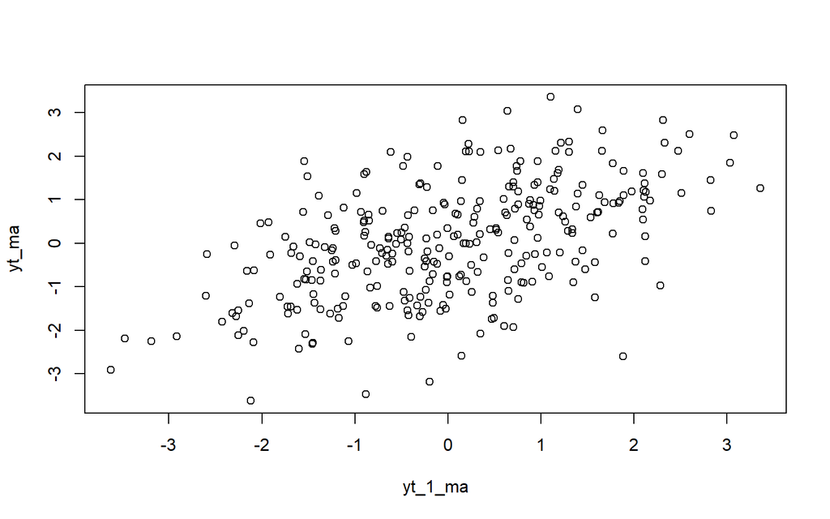

```r
plot(y=yt_ma,x=yt_1_ma)
```

Berdasarkan scatterplot tersebut, terlihat bahwa terdapat hubungan positif antara $Y_t$ dengan $Y_{t-1}$. Hal ini sesuai dengan teori yang ada

```r
cor(yt_ma,yt_1_ma)
```

```
## [1] 0.5274606
```

Korelasi antara $Y_t$ dengan $Y_{t-1}$ dari hasil simulasi mendekati perhitungan teoritis yaitu

$$\rho_1=\frac{-\theta_1 + \theta_1
\theta_2}{1+(-\theta_1)^2+(-\theta_2)^2}=\frac{(-0.4) +
(0,4)(0,6)}{1+(0.4)^2 + (0,6)^2}=0.421053$$

#### Korelasi antara $Y_t$ dengan $Y_{t-2}$

```r
#Yt
yt_ma2 <- ma[-c(1,2)]
yt_ma2
```

```
##   [1]  0.471173424 -1.745463687  0.141510314 -0.729712854 -0.114842790
##   [6] -0.472894305 -1.127948717 -1.443797742 -1.171879031 -1.723286222
##  [11] -1.461924092 -0.845074607  0.519525249  0.312187420  0.020572732
##  [16] -1.181770516 -1.508255550  1.534249256  0.598119283  1.012450498
##  [21] -0.556369299 -0.011041246 -0.774213194 -1.449939345 -0.420758391
##  [26] -1.662676381 -0.079747157 -1.556197355  0.718835126 -0.596243221
##  [31] -0.238298741 -1.070389923 -2.255260716 -2.120011486 -3.624543435
##  [36] -2.913580609 -2.138714925 -1.388210999  1.086560934 -0.768382742
##  [41] -0.413123964 -1.263954490 -1.619808057 -1.534624150 -2.091327966
##  [46] -2.276021753 -1.689013389 -1.457572736 -2.319068111 -1.602598402
##  [51] -2.425338748 -1.807763414 -1.233628102 -0.110845196  1.775654086
##  [56]  0.223607057  2.285258743 -0.979456751  1.157010823  2.116941328
##  [61]  1.378789117  0.845856907 -0.296314421  1.372262398 -0.432336811
##  [66]  1.978634754  1.193531021  1.688995021  0.939220832 -0.250827924
##  [71] -0.544575725  0.228395751  2.109671129  1.063681873 -0.209897795
```

[output cut: 45 more lines]

```r
#Yt-2
yt_2_ma <- ma[-c(299,300)]
yt_2_ma
```

```
##   [1] -1.207065749  0.277429242  0.471173424 -1.745463687  0.141510314
##   [6] -0.729712854 -0.114842790 -0.472894305 -1.127948717 -1.443797742
##  [11] -1.171879031 -1.723286222 -1.461924092 -0.845074607  0.519525249
##  [16]  0.312187420  0.020572732 -1.181770516 -1.508255550  1.534249256
##  [21]  0.598119283  1.012450498 -0.556369299 -0.011041246 -0.774213194
##  [26] -1.449939345 -0.420758391 -1.662676381 -0.079747157 -1.556197355
##  [31]  0.718835126 -0.596243221 -0.238298741 -1.070389923 -2.255260716
##  [36] -2.120011486 -3.624543435 -2.913580609 -2.138714925 -1.388210999
##  [41]  1.086560934 -0.768382742 -0.413123964 -1.263954490 -1.619808057
##  [46] -1.534624150 -2.091327966 -2.276021753 -1.689013389 -1.457572736
##  [51] -2.319068111 -1.602598402 -2.425338748 -1.807763414 -1.233628102
##  [56] -0.110845196  1.775654086  0.223607057  2.285258743 -0.979456751
##  [61]  1.157010823  2.116941328  1.378789117  0.845856907 -0.296314421
##  [66]  1.372262398 -0.432336811  1.978634754  1.193531021  1.688995021
##  [71]  0.939220832 -0.250827924 -0.544575725  0.228395751  2.109671129
```

[output cut: 45 more lines]

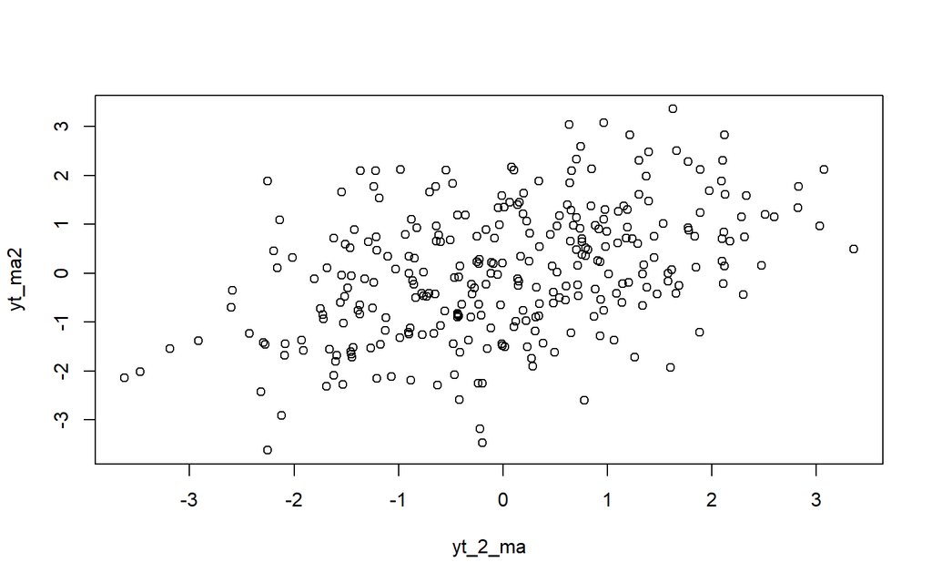

```r
plot(y=yt_ma2,x=yt_2_ma)
```

Berdasarkan scatterplot tersebut, terlihat bahwa cenderung terdapat hubungan antara $Y_t$ dengan $Y_{t-2}$.

```r
cor(yt_ma2,yt_2_ma)
```

```
## [1] 0.4339293
```

Korelasi antara $Y_t$ dengan $Y_{t-2}$ dari hasil simulasi mendekati perhitungan teoritis yaitu
$$\rho_2=\frac{-\theta_2}{1+(\theta_1)^2+(\theta_2)^2}=\frac{-(-0,6)}{1+(0,4)^2
+ (0,6)^2}=0.394737$$

```r
#Yt
yt_ma3 <- ma[-c(1:3)]
yt_ma3
```

```
##   [1] -1.745463687  0.141510314 -0.729712854 -0.114842790 -0.472894305
##   [6] -1.127948717 -1.443797742 -1.171879031 -1.723286222 -1.461924092
##  [11] -0.845074607  0.519525249  0.312187420  0.020572732 -1.181770516
##  [16] -1.508255550  1.534249256  0.598119283  1.012450498 -0.556369299
##  [21] -0.011041246 -0.774213194 -1.449939345 -0.420758391 -1.662676381
##  [26] -0.079747157 -1.556197355  0.718835126 -0.596243221 -0.238298741
##  [31] -1.070389923 -2.255260716 -2.120011486 -3.624543435 -2.913580609
##  [36] -2.138714925 -1.388210999  1.086560934 -0.768382742 -0.413123964
##  [41] -1.263954490 -1.619808057 -1.534624150 -2.091327966 -2.276021753
##  [46] -1.689013389 -1.457572736 -2.319068111 -1.602598402 -2.425338748
##  [51] -1.807763414 -1.233628102 -0.110845196  1.775654086  0.223607057
##  [56]  2.285258743 -0.979456751  1.157010823  2.116941328  1.378789117
##  [61]  0.845856907 -0.296314421  1.372262398 -0.432336811  1.978634754
##  [66]  1.193531021  1.688995021  0.939220832 -0.250827924 -0.544575725
##  [71]  0.228395751  2.109671129  1.063681873 -0.209897795 -1.371901203
```

[output cut: 45 more lines]

```r
#Yt-3
yt_3_ma <- ma[-c(298:300)]
yt_3_ma
```

```
##   [1] -1.207065749  0.277429242  0.471173424 -1.745463687  0.141510314
##   [6] -0.729712854 -0.114842790 -0.472894305 -1.127948717 -1.443797742
##  [11] -1.171879031 -1.723286222 -1.461924092 -0.845074607  0.519525249
##  [16]  0.312187420  0.020572732 -1.181770516 -1.508255550  1.534249256
##  [21]  0.598119283  1.012450498 -0.556369299 -0.011041246 -0.774213194
##  [26] -1.449939345 -0.420758391 -1.662676381 -0.079747157 -1.556197355
##  [31]  0.718835126 -0.596243221 -0.238298741 -1.070389923 -2.255260716
##  [36] -2.120011486 -3.624543435 -2.913580609 -2.138714925 -1.388210999
##  [41]  1.086560934 -0.768382742 -0.413123964 -1.263954490 -1.619808057
##  [46] -1.534624150 -2.091327966 -2.276021753 -1.689013389 -1.457572736
##  [51] -2.319068111 -1.602598402 -2.425338748 -1.807763414 -1.233628102
##  [56] -0.110845196  1.775654086  0.223607057  2.285258743 -0.979456751
##  [61]  1.157010823  2.116941328  1.378789117  0.845856907 -0.296314421
##  [66]  1.372262398 -0.432336811  1.978634754  1.193531021  1.688995021
##  [71]  0.939220832 -0.250827924 -0.544575725  0.228395751  2.109671129
```

[output cut: 45 more lines]

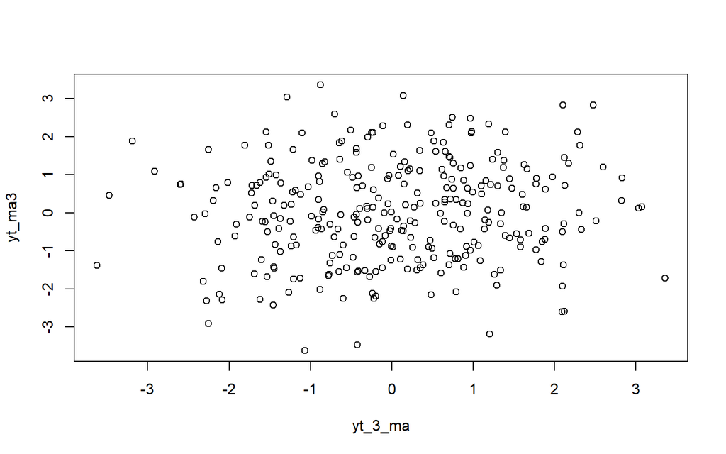

```r
plot(y=yt_ma3,x=yt_3_ma)
```

Berdasarkan scatterplot tersebut, terlihat bahwa cenderung tidak terdapat hubungan antara $Y_t$ dengan $Y_{t-3}$.

```r
cor(yt_ma3,yt_3_ma)
```

```
## [1] 0.08555282
```

Korelasi antara $Y_t$ dengan $Y_{t-3}$ hasil simulasi mendekati teori yang ada yaitu 0.

# AR(2)

## Proses AR

Proses AR dapat dituliskan sebagai berikut:

$$y_{t} = c + e_t + \phi_{1}Y_{t-1} +
\phi_{2}Y_{t-2} + \dots + \phi_{q}Y_{t-q} = c+{e_t+\sum_{i=1}^p
\phi_iY_{t-i}}$$
Terlihat bahwa $Y_t$ berperan penting dalam pembangkitan proses AR.

## Pembangkitan Proses AR

Akan dicoba membangkitkan proses AR paling sederhana, yaitu AR(2) dengan $\phi_1 = 0.5$ dan $\phi_2 = 0.2$ sebanyak 300 observasi dan $c=0$.

Nilai-nilai selanjutnya dapat dicari melalui *loop*. Bentuk loop dapat dilihat dari rumus AR(2) yang hendak dibangkitkan:

$$Y_t = e_t+0.5Y_{t-1}+0.2Y_{t-2}$$

```r
set.seed(1231)
n<-length(wn)
n
```

```
## [1] 300
```

```r
ar <- c(2:n)
for (i in 3:n) {ar[i]<-wn[i]+0.5*ar[i-1]+0.2*ar[i-2]}
ar
```

```
##   [1]  2.0000000000  3.0000000000  2.9844411767 -0.2534771143  0.8992743670
##   [6]  0.9049976528  0.0576137397 -0.3368254554 -0.7213419789 -1.3180739095
##  [11] -1.2804980503 -1.9022502519 -1.9834786307 -1.3077305484 -0.0910669414
##  [16] -0.4173650748 -0.7379054315 -1.3636211473 -1.6665633402  1.3098292789
##  [21]  0.4556901916 -0.0008749451 -0.3498473066  0.2844907987 -0.6214443089
##  [26] -1.7020289051 -0.4005475934 -1.5643353007 -0.8774154694 -1.6875233960
##  [31]  0.0830527543 -0.7715713809 -1.0786151771 -1.1948799253 -2.4422564672
##  [36] -2.6277234807 -3.9823526828 -3.8577142296 -3.0196215101 -2.7472511414
##  [41] -0.5280536074 -1.8821197557 -1.9020352331 -1.6080645696 -2.1787794077
##  [46] -2.3795169357 -2.7328325420 -3.0943055438 -2.6175473993 -2.4244847657
##  [51] -3.5417831195 -2.8378644376 -3.2361784671 -3.2006241306 -2.4098572823
##  [56] -1.2819976482  0.5248471922 -0.7673293575  1.3272143886 -0.6476672249
##  [61]  0.5981977296  2.7185564905  1.4441574014  0.5961564191  0.5793049341
##  [66]  2.1859681990  0.0702373496  1.8401394940  2.2636820077  1.8363416999
##  [71]  1.3778000899  0.6006996468  0.2093859085  0.8731194511  2.5487077686
```

[output cut: 45 more lines]

Selain menggunakan cara di atas, pembangkitan proses AR dapat dilakukan dengan fungsi `arima.sim()` sebagai berikut.

```r
ar2 <- arima.sim(list(order=c(2,0,0), ar=c(0.5 , 0.2)), n=300)
ar2
```

```
## Time Series:
## Start = 1
## End = 300
## Frequency = 1
##   [1]  0.062674936  0.792148571 -0.751511327  0.696794531 -0.285043385
##   [6] -0.755767841 -1.017433943  0.387320240  0.647811547  0.298625951
##  [11]  1.241260952  1.525861963  2.756209695  1.122692962  1.615143406
##  [16]  0.904156940  0.317785921 -1.053091640 -0.419370348 -0.680476617
##  [21] -0.984365985  1.852474081  0.897593126  0.614860339  0.867733233
##  [26] -0.555789542 -2.756043552 -2.874323548 -3.028204561 -2.186660804
##  [31] -1.020403264 -1.002354509  0.102070336  0.847973967  1.069780340
##  [36]  2.450123877  0.813198814  0.001598103 -0.405903344 -0.733357410
##  [41] -0.290965752 -1.904231929 -2.679816518 -2.336035504 -1.152208925
##  [46] -2.173393345 -2.508690376 -1.179319942 -1.970533016 -1.716685729
##  [51] -0.968064762 -1.349847747  0.365478777  1.590727187  0.689576628
```

[output cut: 49 more lines]

## Karakteristik AR(2)

### Plot Time Series

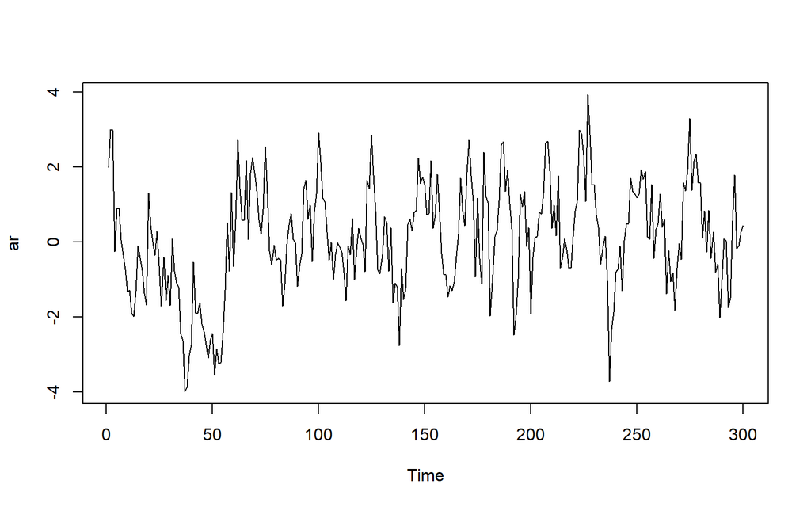

```r
ts.plot(ar)
```

Berdasarkan plot time series tersebut terlihat bahwa data cenderung stasioner pada rataan

### Plot ACF

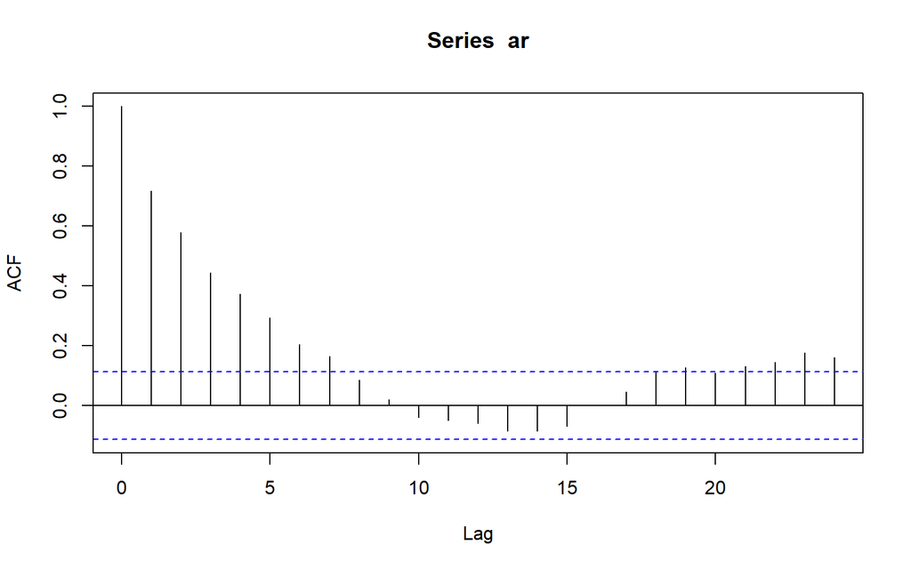

```r
acf(ar)
```

Berdasarkan plot ACF tersebut terlihat bahwa plot ACF cenderung *tails off*

### Plot PACF

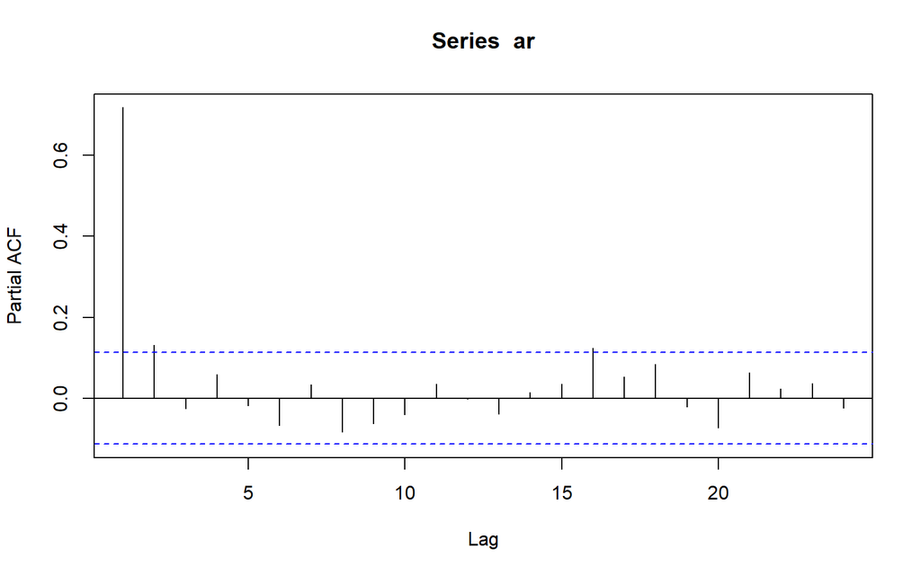

```r
pacf(ar)
```

Berdasarkan plot PACF tersebut, terlihat bahwa plot PACF *cuts off* pada lag kedua, sejalan dengan teori yang ada

### Plot EACF

```r
TSA::eacf(ar)
```

```
## AR/MA
##   0 1 2 3 4 5 6 7 8 9 10 11 12 13
## 0 x x x x x x x o o o o  o  o  o
## 1 x o o o o o o o o o o  o  o  o
## 2 x o o o o o o o o o o  o  o  o
## 3 x x o o o o o o o o o  o  o  o
## 4 x x o o o o o o o o o  o  o  o
## 5 x x x x o o x o o o o  o  o  o
## 6 x x x x o o o o o o o  o  o  o
## 7 x x x o x x o o o o o  o  o  o
```

Berdasarkan pola segitiga nol pada plot EACF, terlihat bahwa segitiga nol berada pada ordo AR(0) dan ordo MA(7)

### Scatterplot Antar Lag

#### Korelasi antara $Y_t$ dengan $Y_{t-1}$

```r
#Yt
yt_ar <- ar[-1]
yt_ar
```

```
##   [1]  3.0000000000  2.9844411767 -0.2534771143  0.8992743670  0.9049976528
##   [6]  0.0576137397 -0.3368254554 -0.7213419789 -1.3180739095 -1.2804980503
##  [11] -1.9022502519 -1.9834786307 -1.3077305484 -0.0910669414 -0.4173650748
##  [16] -0.7379054315 -1.3636211473 -1.6665633402  1.3098292789  0.4556901916
##  [21] -0.0008749451 -0.3498473066  0.2844907987 -0.6214443089 -1.7020289051
##  [26] -0.4005475934 -1.5643353007 -0.8774154694 -1.6875233960  0.0830527543
##  [31] -0.7715713809 -1.0786151771 -1.1948799253 -2.4422564672 -2.6277234807
##  [36] -3.9823526828 -3.8577142296 -3.0196215101 -2.7472511414 -0.5280536074
##  [41] -1.8821197557 -1.9020352331 -1.6080645696 -2.1787794077 -2.3795169357
##  [46] -2.7328325420 -3.0943055438 -2.6175473993 -2.4244847657 -3.5417831195
##  [51] -2.8378644376 -3.2361784671 -3.2006241306 -2.4098572823 -1.2819976482
##  [56]  0.5248471922 -0.7673293575  1.3272143886 -0.6476672249  0.5981977296
##  [61]  2.7185564905  1.4441574014  0.5961564191  0.5793049341  2.1859681990
##  [66]  0.0702373496  1.8401394940  2.2636820077  1.8363416999  1.3778000899
##  [71]  0.6006996468  0.2093859085  0.8731194511  2.5487077686  1.2955793620
```

[output cut: 45 more lines]

```r
#Yt-1
yt_1_ar <- ar[-300]
yt_1_ar
```

```
##   [1]  2.0000000000  3.0000000000  2.9844411767 -0.2534771143  0.8992743670
##   [6]  0.9049976528  0.0576137397 -0.3368254554 -0.7213419789 -1.3180739095
##  [11] -1.2804980503 -1.9022502519 -1.9834786307 -1.3077305484 -0.0910669414
##  [16] -0.4173650748 -0.7379054315 -1.3636211473 -1.6665633402  1.3098292789
##  [21]  0.4556901916 -0.0008749451 -0.3498473066  0.2844907987 -0.6214443089
##  [26] -1.7020289051 -0.4005475934 -1.5643353007 -0.8774154694 -1.6875233960
##  [31]  0.0830527543 -0.7715713809 -1.0786151771 -1.1948799253 -2.4422564672
##  [36] -2.6277234807 -3.9823526828 -3.8577142296 -3.0196215101 -2.7472511414
##  [41] -0.5280536074 -1.8821197557 -1.9020352331 -1.6080645696 -2.1787794077
##  [46] -2.3795169357 -2.7328325420 -3.0943055438 -2.6175473993 -2.4244847657
##  [51] -3.5417831195 -2.8378644376 -3.2361784671 -3.2006241306 -2.4098572823
##  [56] -1.2819976482  0.5248471922 -0.7673293575  1.3272143886 -0.6476672249
##  [61]  0.5981977296  2.7185564905  1.4441574014  0.5961564191  0.5793049341
##  [66]  2.1859681990  0.0702373496  1.8401394940  2.2636820077  1.8363416999
##  [71]  1.3778000899  0.6006996468  0.2093859085  0.8731194511  2.5487077686
```

[output cut: 45 more lines]

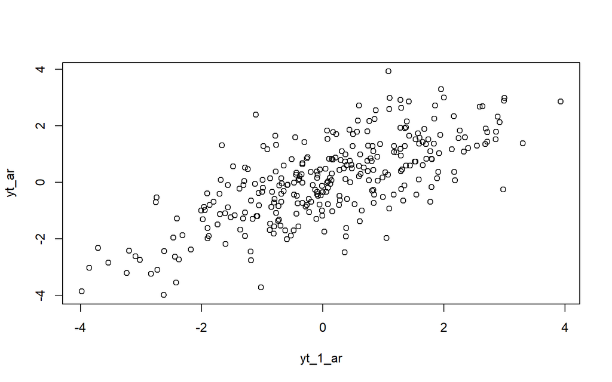

```r
plot(y=yt_ar,x=yt_1_ar)
```

Berdasarkan scatterplot tersebut, terlihat bahwa terdapat hubungan positif antara $Y_t$ dengan $Y_{t-1}$. Hal ini sesuai dengan teori yang ada

```r
cor(yt_ar,yt_1_ar)
```

```
## [1] 0.7204526
```

Korelasi antara $Y_t$ dengan $Y_{t-1}$ dari hasil simulasi mendekati perhitungan teoritis yaitu $\frac{\phi_1}{1-\phi_2}=\frac{0,5}{1-0,2} = 0,625$

#### Korelasi antara $Y_t$ dengan $Y_{t-2}$

```r
#Yt
yt_ar2 <- ar[-c(1,2)]
yt_ar2
```

```
##   [1]  2.9844411767 -0.2534771143  0.8992743670  0.9049976528  0.0576137397
##   [6] -0.3368254554 -0.7213419789 -1.3180739095 -1.2804980503 -1.9022502519
##  [11] -1.9834786307 -1.3077305484 -0.0910669414 -0.4173650748 -0.7379054315
##  [16] -1.3636211473 -1.6665633402  1.3098292789  0.4556901916 -0.0008749451
##  [21] -0.3498473066  0.2844907987 -0.6214443089 -1.7020289051 -0.4005475934
##  [26] -1.5643353007 -0.8774154694 -1.6875233960  0.0830527543 -0.7715713809
##  [31] -1.0786151771 -1.1948799253 -2.4422564672 -2.6277234807 -3.9823526828
##  [36] -3.8577142296 -3.0196215101 -2.7472511414 -0.5280536074 -1.8821197557
##  [41] -1.9020352331 -1.6080645696 -2.1787794077 -2.3795169357 -2.7328325420
##  [46] -3.0943055438 -2.6175473993 -2.4244847657 -3.5417831195 -2.8378644376
##  [51] -3.2361784671 -3.2006241306 -2.4098572823 -1.2819976482  0.5248471922
##  [56] -0.7673293575  1.3272143886 -0.6476672249  0.5981977296  2.7185564905
##  [61]  1.4441574014  0.5961564191  0.5793049341  2.1859681990  0.0702373496
##  [66]  1.8401394940  2.2636820077  1.8363416999  1.3778000899  0.6006996468
##  [71]  0.2093859085  0.8731194511  2.5487077686  1.2955793620 -0.2331697120
```

[output cut: 45 more lines]

```r
#Yt-2
yt_2_ar <- ar[-c(299,300)]
yt_2_ar
```

```
##   [1]  2.0000000000  3.0000000000  2.9844411767 -0.2534771143  0.8992743670
##   [6]  0.9049976528  0.0576137397 -0.3368254554 -0.7213419789 -1.3180739095
##  [11] -1.2804980503 -1.9022502519 -1.9834786307 -1.3077305484 -0.0910669414
##  [16] -0.4173650748 -0.7379054315 -1.3636211473 -1.6665633402  1.3098292789
##  [21]  0.4556901916 -0.0008749451 -0.3498473066  0.2844907987 -0.6214443089
##  [26] -1.7020289051 -0.4005475934 -1.5643353007 -0.8774154694 -1.6875233960
##  [31]  0.0830527543 -0.7715713809 -1.0786151771 -1.1948799253 -2.4422564672
##  [36] -2.6277234807 -3.9823526828 -3.8577142296 -3.0196215101 -2.7472511414
##  [41] -0.5280536074 -1.8821197557 -1.9020352331 -1.6080645696 -2.1787794077
##  [46] -2.3795169357 -2.7328325420 -3.0943055438 -2.6175473993 -2.4244847657
##  [51] -3.5417831195 -2.8378644376 -3.2361784671 -3.2006241306 -2.4098572823
##  [56] -1.2819976482  0.5248471922 -0.7673293575  1.3272143886 -0.6476672249
##  [61]  0.5981977296  2.7185564905  1.4441574014  0.5961564191  0.5793049341
##  [66]  2.1859681990  0.0702373496  1.8401394940  2.2636820077  1.8363416999
##  [71]  1.3778000899  0.6006996468  0.2093859085  0.8731194511  2.5487077686
```

[output cut: 45 more lines]

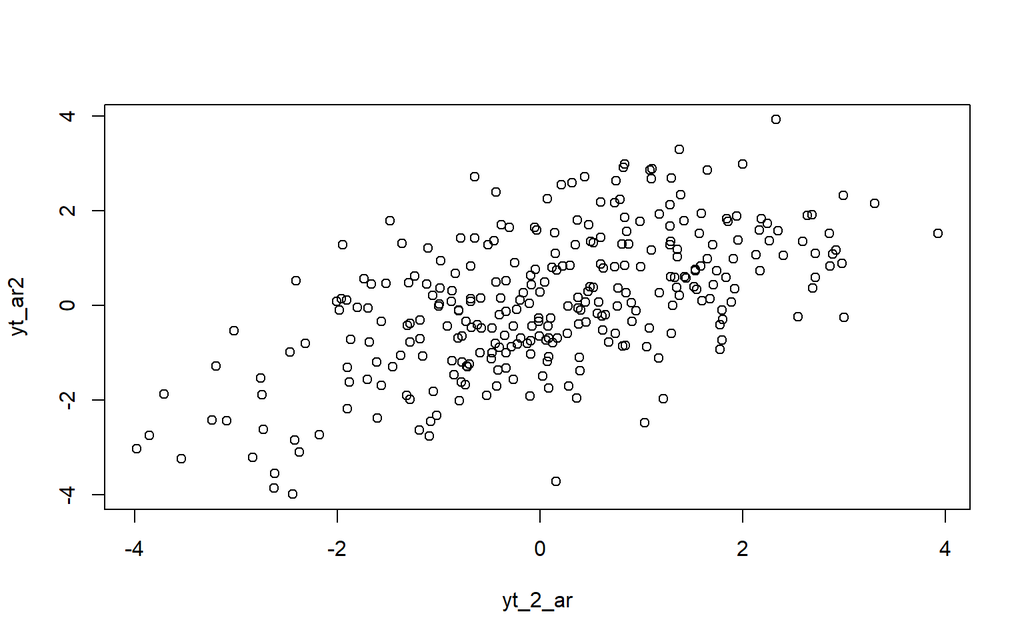

```r
plot(y=yt_ar2,x=yt_2_ar)
```

Berdasarkan scatterplot tersebut, terlihat bahwa terdapat hubungan positif antara $Y_t$ dengan $Y_{t-2}$. Hal ini sesuai dengan teori yang ada

```r
cor(yt_ar2,yt_2_ar)
```

```
## [1] 0.5849121
```

Korelasi antara $Y_t$ dengan $Y_{t-2}$ dari hasil simulasi mendekati perhitungan teoritis yaitu $\frac{\phi_2(1-\phi_2)+\phi_1^2}{1-\phi_2}=\frac{0,2(1-0,2)+0,5^2}{1-0,2}=0.5125$.

#### Korelasi antara $Y_t$ dengan $Y_{t-3}$

```r
#Yt
yt_ar3 <- ar[-c(1:3)]
yt_ar3
```

```
##   [1] -0.2534771143  0.8992743670  0.9049976528  0.0576137397 -0.3368254554
##   [6] -0.7213419789 -1.3180739095 -1.2804980503 -1.9022502519 -1.9834786307
##  [11] -1.3077305484 -0.0910669414 -0.4173650748 -0.7379054315 -1.3636211473
##  [16] -1.6665633402  1.3098292789  0.4556901916 -0.0008749451 -0.3498473066
##  [21]  0.2844907987 -0.6214443089 -1.7020289051 -0.4005475934 -1.5643353007
##  [26] -0.8774154694 -1.6875233960  0.0830527543 -0.7715713809 -1.0786151771
##  [31] -1.1948799253 -2.4422564672 -2.6277234807 -3.9823526828 -3.8577142296
##  [36] -3.0196215101 -2.7472511414 -0.5280536074 -1.8821197557 -1.9020352331
##  [41] -1.6080645696 -2.1787794077 -2.3795169357 -2.7328325420 -3.0943055438
##  [46] -2.6175473993 -2.4244847657 -3.5417831195 -2.8378644376 -3.2361784671
##  [51] -3.2006241306 -2.4098572823 -1.2819976482  0.5248471922 -0.7673293575
##  [56]  1.3272143886 -0.6476672249  0.5981977296  2.7185564905  1.4441574014
##  [61]  0.5961564191  0.5793049341  2.1859681990  0.0702373496  1.8401394940
##  [66]  2.2636820077  1.8363416999  1.3778000899  0.6006996468  0.2093859085
##  [71]  0.8731194511  2.5487077686  1.2955793620 -0.2331697120 -0.5810507607
```

[output cut: 45 more lines]

```r
#Yt-3
yt_3_ar <- ar[-c(298:300)]
yt_3_ar
```

```
##   [1]  2.0000000000  3.0000000000  2.9844411767 -0.2534771143  0.8992743670
##   [6]  0.9049976528  0.0576137397 -0.3368254554 -0.7213419789 -1.3180739095
##  [11] -1.2804980503 -1.9022502519 -1.9834786307 -1.3077305484 -0.0910669414
##  [16] -0.4173650748 -0.7379054315 -1.3636211473 -1.6665633402  1.3098292789
##  [21]  0.4556901916 -0.0008749451 -0.3498473066  0.2844907987 -0.6214443089
##  [26] -1.7020289051 -0.4005475934 -1.5643353007 -0.8774154694 -1.6875233960
##  [31]  0.0830527543 -0.7715713809 -1.0786151771 -1.1948799253 -2.4422564672
##  [36] -2.6277234807 -3.9823526828 -3.8577142296 -3.0196215101 -2.7472511414
##  [41] -0.5280536074 -1.8821197557 -1.9020352331 -1.6080645696 -2.1787794077
##  [46] -2.3795169357 -2.7328325420 -3.0943055438 -2.6175473993 -2.4244847657
##  [51] -3.5417831195 -2.8378644376 -3.2361784671 -3.2006241306 -2.4098572823
##  [56] -1.2819976482  0.5248471922 -0.7673293575  1.3272143886 -0.6476672249
##  [61]  0.5981977296  2.7185564905  1.4441574014  0.5961564191  0.5793049341
##  [66]  2.1859681990  0.0702373496  1.8401394940  2.2636820077  1.8363416999
##  [71]  1.3778000899  0.6006996468  0.2093859085  0.8731194511  2.5487077686
```

[output cut: 45 more lines]

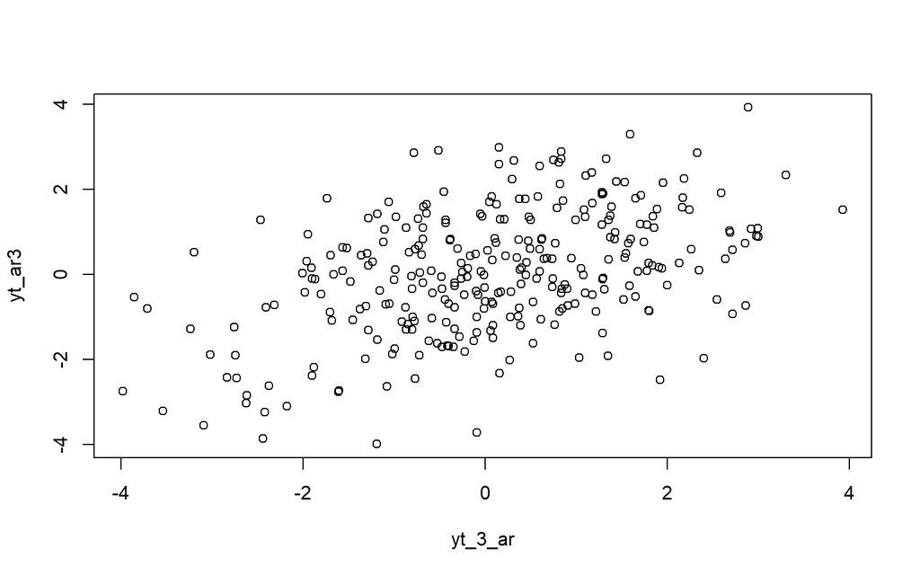

```r
plot(y=yt_ar3,x=yt_3_ar)
```

Berdasarkan scatterplot tersebut, terlihat bahwa terdapat hubungan positif antara $Y_t$ dengan $Y_{t-3}$. Hal ini sesuai dengan teori yang ada

```r
cor(yt_ar3,yt_3_ar)
```

```
## [1] 0.4506458
```

# ARMA (2,2)

## Fungsi pembangkitan ARMA

Bentuk umum data berpola ARMA.

$$y_{t} = c + \sum_{i=1}^p \phi_{i}y_{t-i} + \sum_{j=1}^q e_{t-j}+ e_{t}$$

```r
arma.sim <- function(n, macoef, arcoef){
  manum <- length(macoef)
  arnum <- length(arcoef)
  stopifnot(manum < n & arnum < n)

  wn <- rnorm(n, sd = 0.5)
  init <- max(manum, arnum)

  arma <- wn[1:init]
  for(i in {init+1}:n){
   mastart <- i - manum
   maend <- i-1
   arstart <- i - arnum
   arend <- i-1
   arma[i] <- sum(arcoef * arma[arstart:arend]) + sum(macoef * wn[mastart:maend])  + wn[i]
   }
  return(arma)
}
```

```r
arma22 <- arma.sim(300, c(0.4, 0.6), c(0.5,0.2))

arma22 |> arima(c(2,0,2))
```

```
##
## Call:
## arima(x = arma22, order = c(2, 0, 2))
##
## Coefficients:
##          ar1     ar2     ma1     ma2  intercept
##       0.2898  0.4543  0.5073  0.3680    -0.2076
## s.e.  0.1077  0.1041  0.1051  0.0655     0.2047
##
## sigma^2 estimated as 0.2425:  log likelihood = -214.12,  aic = 440.24
```

```r
set.seed(1234)
n = length(wn)
phi1 = 0.5
phi2 = 0.2
theta1 = 0.4
theta2 = 0.6

y.arma=c(2:n)
for (i in 3:n){y.arma[i] = phi1*y.arma[i-1] + phi2*y.arma[i-2] + theta1*wn[i-1] + theta2*wn[i-2]}
y.arma
```

```
##   [1]  2.000000000  3.000000000  1.286732247  1.843600140  0.891532144
##   [6] -0.421282646  0.427562276  0.203262160 -0.376353183 -0.701284073
##  [11] -1.120599004 -1.425456094 -1.622518046 -2.005883666 -1.767414252
##  [16] -0.862410945 -0.253106085 -0.569610331 -1.006510253 -1.498763115
##  [21] -0.486652545  0.960057500  0.266876814 -0.145180780 -0.099707974
##  [26] -0.080624577 -1.055767996 -1.183029571 -0.867277241 -1.290493289
##  [31] -1.202164513 -0.979831057 -0.259207135 -0.894701641 -1.125359494
##  [36] -1.694012299 -2.516581835 -3.169680794 -3.932577830 -3.522538533
##  [41] -2.910720164 -1.859607807 -1.069707266 -1.890106682 -1.784462775
##  [46] -1.836362556 -2.259083606 -2.520850182 -2.877427082 -2.903606356
##  [51] -2.540325449 -2.871406473 -3.260217450 -2.997191424 -3.221957781
##  [56] -2.884318190 -1.958714038 -0.559260176  0.007976218  0.070487871
##  [61]  0.537261537 -0.149321400  1.446341114  2.208796764  1.104956939
##  [66]  0.589415772  1.221970200  1.339675828  0.778198184  2.009556482
##  [71]  2.092745871  1.652925045  1.066959905  0.444174145  0.474879321
```

[output cut: 45 more lines]

Pembangkitan ARMA(p,q) juga dapat dilakukan dengan fungsi `arima.sim` sebagai berikut.

```r
arma22 <- arima.sim(list(order=c(2,0,2), ar = c(0.5,0.2), ma = c(0.4, 0.6)), n=300)
arma22
```

```
## Time Series:
## Start = 1
## End = 300
## Frequency = 1
##   [1] -2.75189059 -1.74814288 -2.98064692 -1.12111691 -1.75293106 -1.33898765
##   [7] -2.09046996 -3.56829323 -4.32225209 -6.49932813 -7.02769509 -6.95242810
##  [13] -6.26996407 -3.43890672 -3.74182891 -2.97181976 -3.49823015 -3.96328709
##  [19] -4.21591372 -4.99194225 -5.61517562 -5.49498965 -5.32810268 -6.08211738
##  [25] -5.70927763 -6.49640104 -6.19781946 -5.63181804 -4.16631811 -1.43386858
##  [31] -1.32659085  1.33518960 -0.57718012  1.13545868  2.56923465  2.89049818
##  [37]  2.80495292  1.68426168  2.77538382  1.29220743  3.17981524  3.04188012
##  [43]  3.84589813  3.47054592  2.25362466  1.27634579  1.31729358  3.02358708
##  [49]  2.83893413  1.81428668  0.10302896 -0.45121970 -0.85290753 -0.66635425
##  [55] -0.93510416 -2.14779642 -2.08562341 -1.51503473 -0.24121274  0.91556687
##  [61]  0.64537308  0.48311177 -1.14217407 -1.12039092 -1.27141453  0.91636167
```

[output cut: 39 more lines]

## Karakteristik ARMA(2,2)

### Plot Time Series

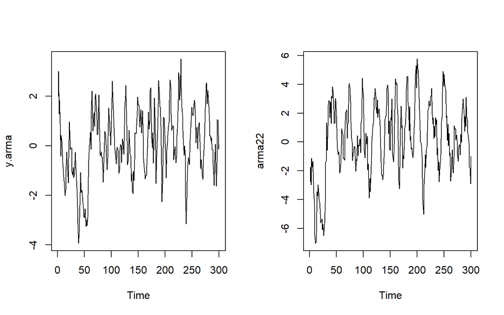

```r
par(mfrow = c(1, 2))
ts.plot(y.arma)
ts.plot(arma22)
```

```r
par(mfrow = c(2, 2))
```

Berdasarkan plot time series tersebut, terlihat bahwa model ARMA(2,2) cenderung stasioner dalam rataan

### Plot ACF

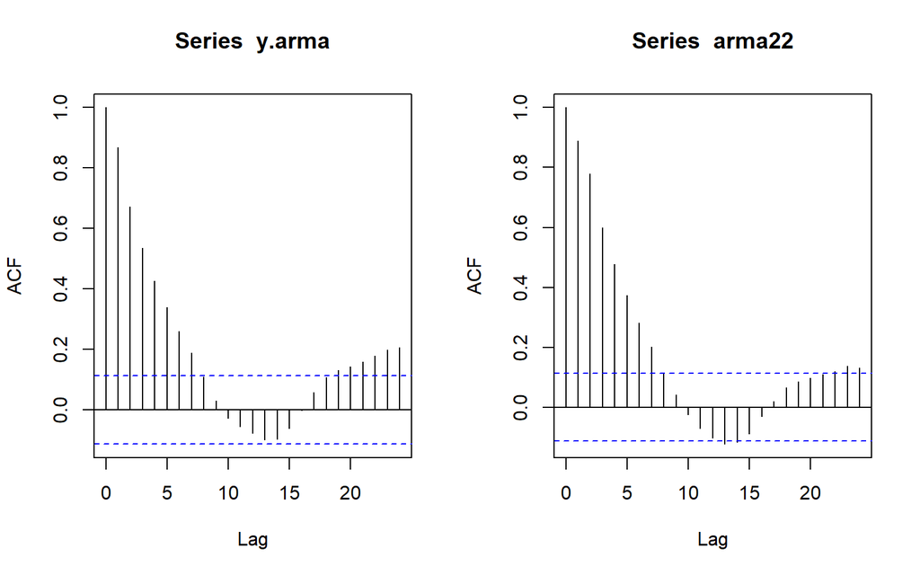

```r
par(mfrow = c(1, 2))
acf(y.arma)
acf(arma22)
```

```r
par(mfrow = c(2, 2))
```

Berdasarkan plot ACF tersebut, terlihat bahwa model ARMA(2,2) hasil simulasi memiliki plot ACF yang *tails off*, sesuai dengan teori yang ada

### Plot PACF

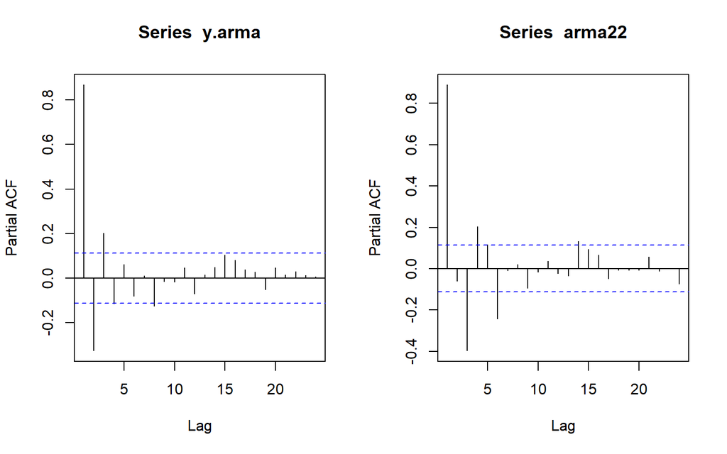

```r
par(mfrow = c(1, 2))
pacf(y.arma)
pacf(arma22)
```

```r
par(mfrow = c(2, 2))
```

Berdasarkan plot PACF tersebut, terlihat bahwa model ARMA(2,2) hasil simulasi memiliki plot PACF yang *tails off*, sesuai dengan teori

### Plot EACF

```r
TSA::eacf(y.arma)
```

```
## AR/MA
##   0 1 2 3 4 5 6 7 8 9 10 11 12 13
## 0 x x x x x x x o o o o  o  o  o
## 1 x o o o o o o o o o o  o  o  o
## 2 x x o o o o o o o o o  o  o  o
## 3 x x o o o o o o o o o  o  o  o
## 4 x o x o o o o o o o o  o  o  o
## 5 x x x o o o o o o o o  o  o  o
## 6 x x o o x x o o o o o  o  o  o
## 7 x x o x x o o o o o o  o  o  o
```

```r
TSA::eacf(arma22)
```

```
## AR/MA
##   0 1 2 3 4 5 6 7 8 9 10 11 12 13
## 0 x x x x x x x o o o o  o  x  o
## 1 o x o o o o x o o o o  o  o  o
## 2 x x o o o o o o o o o  o  o  o
## 3 x x x x o o o o o o o  o  o  o
## 4 x x x x o o o o o o o  o  o  o
## 5 x x x x x x x o o o o  o  o  o
## 6 o o x o x x o o o o o  o  o  o
## 7 x o x x x x o x o o o  o  o  o
```

Berdasarkan pola segitiga nol pada plot EACF, terlihat bahwa segitiga nol berada pada ordo AR(0) dan ordo MA(7)

### Scatterplot Antar Lag

#### Korelasi antara $Y_t$ dengan $Y_{t-1}$

```r
#Yt
yt_arma <- arma22[-1]
yt_arma
```

```
##   [1] -1.74814288 -2.98064692 -1.12111691 -1.75293106 -1.33898765 -2.09046996
##   [7] -3.56829323 -4.32225209 -6.49932813 -7.02769509 -6.95242810 -6.26996407
##  [13] -3.43890672 -3.74182891 -2.97181976 -3.49823015 -3.96328709 -4.21591372
##  [19] -4.99194225 -5.61517562 -5.49498965 -5.32810268 -6.08211738 -5.70927763
##  [25] -6.49640104 -6.19781946 -5.63181804 -4.16631811 -1.43386858 -1.32659085
##  [31]  1.33518960 -0.57718012  1.13545868  2.56923465  2.89049818  2.80495292
##  [37]  1.68426168  2.77538382  1.29220743  3.17981524  3.04188012  3.84589813
##  [43]  3.47054592  2.25362466  1.27634579  1.31729358  3.02358708  2.83893413
##  [49]  1.81428668  0.10302896 -0.45121970 -0.85290753 -0.66635425 -0.93510416
##  [55] -2.14779642 -2.08562341 -1.51503473 -0.24121274  0.91556687  0.64537308
##  [61]  0.48311177 -1.14217407 -1.12039092 -1.27141453  0.91636167  2.04091439
##  [67]  2.13232979  2.23257264  0.25301429  1.21071226  1.29939237  3.92904462
##  [73]  4.07112121  3.78513073  2.83160983  1.41191959  0.28488816 -0.04006883
##  [79] -1.28812485 -0.74220308 -0.74424287 -0.32976863 -0.31752860 -0.98342470
##  [85] -2.04217397 -1.20184647 -1.31314616  0.45270778 -0.93468943 -0.20680752
```

[output cut: 35 more lines]

```r
#Yt-1
yt_1_arma <- arma22[-300]
yt_1_arma
```

```
##   [1] -2.75189059 -1.74814288 -2.98064692 -1.12111691 -1.75293106 -1.33898765
##   [7] -2.09046996 -3.56829323 -4.32225209 -6.49932813 -7.02769509 -6.95242810
##  [13] -6.26996407 -3.43890672 -3.74182891 -2.97181976 -3.49823015 -3.96328709
##  [19] -4.21591372 -4.99194225 -5.61517562 -5.49498965 -5.32810268 -6.08211738
##  [25] -5.70927763 -6.49640104 -6.19781946 -5.63181804 -4.16631811 -1.43386858
##  [31] -1.32659085  1.33518960 -0.57718012  1.13545868  2.56923465  2.89049818
##  [37]  2.80495292  1.68426168  2.77538382  1.29220743  3.17981524  3.04188012
##  [43]  3.84589813  3.47054592  2.25362466  1.27634579  1.31729358  3.02358708
##  [49]  2.83893413  1.81428668  0.10302896 -0.45121970 -0.85290753 -0.66635425
##  [55] -0.93510416 -2.14779642 -2.08562341 -1.51503473 -0.24121274  0.91556687
##  [61]  0.64537308  0.48311177 -1.14217407 -1.12039092 -1.27141453  0.91636167
##  [67]  2.04091439  2.13232979  2.23257264  0.25301429  1.21071226  1.29939237
##  [73]  3.92904462  4.07112121  3.78513073  2.83160983  1.41191959  0.28488816
##  [79] -0.04006883 -1.28812485 -0.74220308 -0.74424287 -0.32976863 -0.31752860
##  [85] -0.98342470 -2.04217397 -1.20184647 -1.31314616  0.45270778 -0.93468943
```

[output cut: 35 more lines]

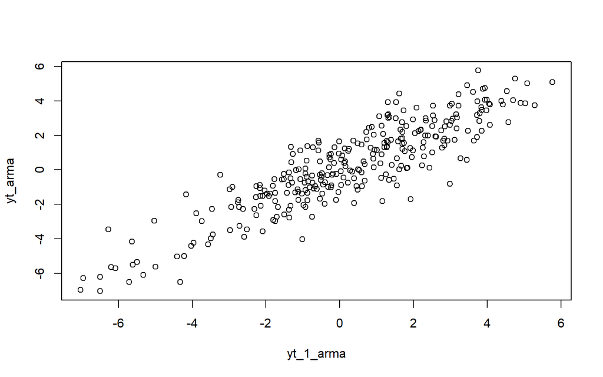

```r
plot(y=yt_arma,x=yt_1_arma)
```

Berdasarkan scatterplot tersebut, terlihat bahwa terdapat hubungan positif antara $Y_t$ dengan $Y_{t-1}$. Hal ini sesuai dengan teori yang ada

```r
cor(yt_arma,yt_1_arma)
```

```
## [1] 0.8918177
```

#### Korelasi antara $Y_t$ dengan $Y_{t-2}$

```r
#Yt
yt_arma2 <- arma22[-c(1,2)]
yt_arma2
```

```
##   [1] -2.98064692 -1.12111691 -1.75293106 -1.33898765 -2.09046996 -3.56829323
##   [7] -4.32225209 -6.49932813 -7.02769509 -6.95242810 -6.26996407 -3.43890672
##  [13] -3.74182891 -2.97181976 -3.49823015 -3.96328709 -4.21591372 -4.99194225
##  [19] -5.61517562 -5.49498965 -5.32810268 -6.08211738 -5.70927763 -6.49640104
##  [25] -6.19781946 -5.63181804 -4.16631811 -1.43386858 -1.32659085  1.33518960
##  [31] -0.57718012  1.13545868  2.56923465  2.89049818  2.80495292  1.68426168
##  [37]  2.77538382  1.29220743  3.17981524  3.04188012  3.84589813  3.47054592
##  [43]  2.25362466  1.27634579  1.31729358  3.02358708  2.83893413  1.81428668
##  [49]  0.10302896 -0.45121970 -0.85290753 -0.66635425 -0.93510416 -2.14779642
##  [55] -2.08562341 -1.51503473 -0.24121274  0.91556687  0.64537308  0.48311177
##  [61] -1.14217407 -1.12039092 -1.27141453  0.91636167  2.04091439  2.13232979
##  [67]  2.23257264  0.25301429  1.21071226  1.29939237  3.92904462  4.07112121
##  [73]  3.78513073  2.83160983  1.41191959  0.28488816 -0.04006883 -1.28812485
##  [79] -0.74220308 -0.74424287 -0.32976863 -0.31752860 -0.98342470 -2.04217397
##  [85] -1.20184647 -1.31314616  0.45270778 -0.93468943 -0.20680752 -0.29613748
```

[output cut: 35 more lines]

```r
#Yt-2
yt_2_arma <- arma22[-c(299,300)]
yt_2_arma
```

```
##   [1] -2.75189059 -1.74814288 -2.98064692 -1.12111691 -1.75293106 -1.33898765
##   [7] -2.09046996 -3.56829323 -4.32225209 -6.49932813 -7.02769509 -6.95242810
##  [13] -6.26996407 -3.43890672 -3.74182891 -2.97181976 -3.49823015 -3.96328709
##  [19] -4.21591372 -4.99194225 -5.61517562 -5.49498965 -5.32810268 -6.08211738
##  [25] -5.70927763 -6.49640104 -6.19781946 -5.63181804 -4.16631811 -1.43386858
##  [31] -1.32659085  1.33518960 -0.57718012  1.13545868  2.56923465  2.89049818
##  [37]  2.80495292  1.68426168  2.77538382  1.29220743  3.17981524  3.04188012
##  [43]  3.84589813  3.47054592  2.25362466  1.27634579  1.31729358  3.02358708
##  [49]  2.83893413  1.81428668  0.10302896 -0.45121970 -0.85290753 -0.66635425
##  [55] -0.93510416 -2.14779642 -2.08562341 -1.51503473 -0.24121274  0.91556687
##  [61]  0.64537308  0.48311177 -1.14217407 -1.12039092 -1.27141453  0.91636167
##  [67]  2.04091439  2.13232979  2.23257264  0.25301429  1.21071226  1.29939237
##  [73]  3.92904462  4.07112121  3.78513073  2.83160983  1.41191959  0.28488816
##  [79] -0.04006883 -1.28812485 -0.74220308 -0.74424287 -0.32976863 -0.31752860
##  [85] -0.98342470 -2.04217397 -1.20184647 -1.31314616  0.45270778 -0.93468943
```

[output cut: 35 more lines]

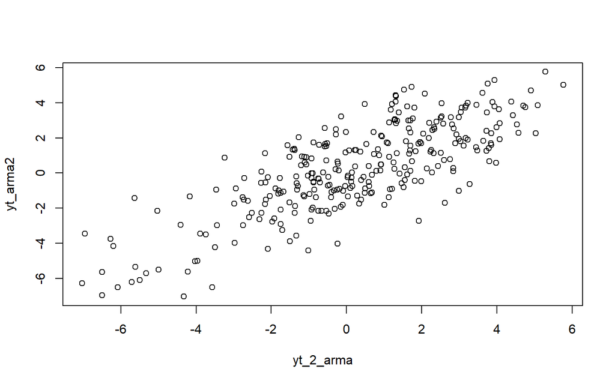

```r
plot(y=yt_arma2,x=yt_2_arma)
```

Berdasarkan scatterplot tersebut, terlihat bahwa terdapat hubungan positif antara $Y_t$ dengan $Y_{t-2}$. Hal ini sesuai dengan teori yang ada

```r
cor(yt_arma2,yt_2_arma)
```

```
## [1] 0.7836583
```

Korelasi antara $Y_t$ dengan $Y_{t-2}$ dari hasil simulasi mendekati perhitungan teoritis.
$$\rho_2=\phi_2 + \phi_1 \rho_1 = 0,2 + (0,5)(0,89) = 0,645$$
#### Korelasi antara $Y_t$ dengan $Y_{t-3}$

```r
#Yt
yt_arma3 <- arma22[-c(1:3)]
yt_arma3
```

```
##   [1] -1.12111691 -1.75293106 -1.33898765 -2.09046996 -3.56829323 -4.32225209
##   [7] -6.49932813 -7.02769509 -6.95242810 -6.26996407 -3.43890672 -3.74182891
##  [13] -2.97181976 -3.49823015 -3.96328709 -4.21591372 -4.99194225 -5.61517562
##  [19] -5.49498965 -5.32810268 -6.08211738 -5.70927763 -6.49640104 -6.19781946
##  [25] -5.63181804 -4.16631811 -1.43386858 -1.32659085  1.33518960 -0.57718012
##  [31]  1.13545868  2.56923465  2.89049818  2.80495292  1.68426168  2.77538382
##  [37]  1.29220743  3.17981524  3.04188012  3.84589813  3.47054592  2.25362466
##  [43]  1.27634579  1.31729358  3.02358708  2.83893413  1.81428668  0.10302896
##  [49] -0.45121970 -0.85290753 -0.66635425 -0.93510416 -2.14779642 -2.08562341
##  [55] -1.51503473 -0.24121274  0.91556687  0.64537308  0.48311177 -1.14217407
##  [61] -1.12039092 -1.27141453  0.91636167  2.04091439  2.13232979  2.23257264
##  [67]  0.25301429  1.21071226  1.29939237  3.92904462  4.07112121  3.78513073
##  [73]  2.83160983  1.41191959  0.28488816 -0.04006883 -1.28812485 -0.74220308
##  [79] -0.74424287 -0.32976863 -0.31752860 -0.98342470 -2.04217397 -1.20184647
##  [85] -1.31314616  0.45270778 -0.93468943 -0.20680752 -0.29613748  0.15497575
```

[output cut: 35 more lines]

```r
#Yt-3
yt_3_arma <- arma22[-c(298:300)]
yt_3_arma
```

```
##   [1] -2.75189059 -1.74814288 -2.98064692 -1.12111691 -1.75293106 -1.33898765
##   [7] -2.09046996 -3.56829323 -4.32225209 -6.49932813 -7.02769509 -6.95242810
##  [13] -6.26996407 -3.43890672 -3.74182891 -2.97181976 -3.49823015 -3.96328709
##  [19] -4.21591372 -4.99194225 -5.61517562 -5.49498965 -5.32810268 -6.08211738
##  [25] -5.70927763 -6.49640104 -6.19781946 -5.63181804 -4.16631811 -1.43386858
##  [31] -1.32659085  1.33518960 -0.57718012  1.13545868  2.56923465  2.89049818
##  [37]  2.80495292  1.68426168  2.77538382  1.29220743  3.17981524  3.04188012
##  [43]  3.84589813  3.47054592  2.25362466  1.27634579  1.31729358  3.02358708
##  [49]  2.83893413  1.81428668  0.10302896 -0.45121970 -0.85290753 -0.66635425
##  [55] -0.93510416 -2.14779642 -2.08562341 -1.51503473 -0.24121274  0.91556687
##  [61]  0.64537308  0.48311177 -1.14217407 -1.12039092 -1.27141453  0.91636167
##  [67]  2.04091439  2.13232979  2.23257264  0.25301429  1.21071226  1.29939237
##  [73]  3.92904462  4.07112121  3.78513073  2.83160983  1.41191959  0.28488816
##  [79] -0.04006883 -1.28812485 -0.74220308 -0.74424287 -0.32976863 -0.31752860
##  [85] -0.98342470 -2.04217397 -1.20184647 -1.31314616  0.45270778 -0.93468943
```

[output cut: 35 more lines]

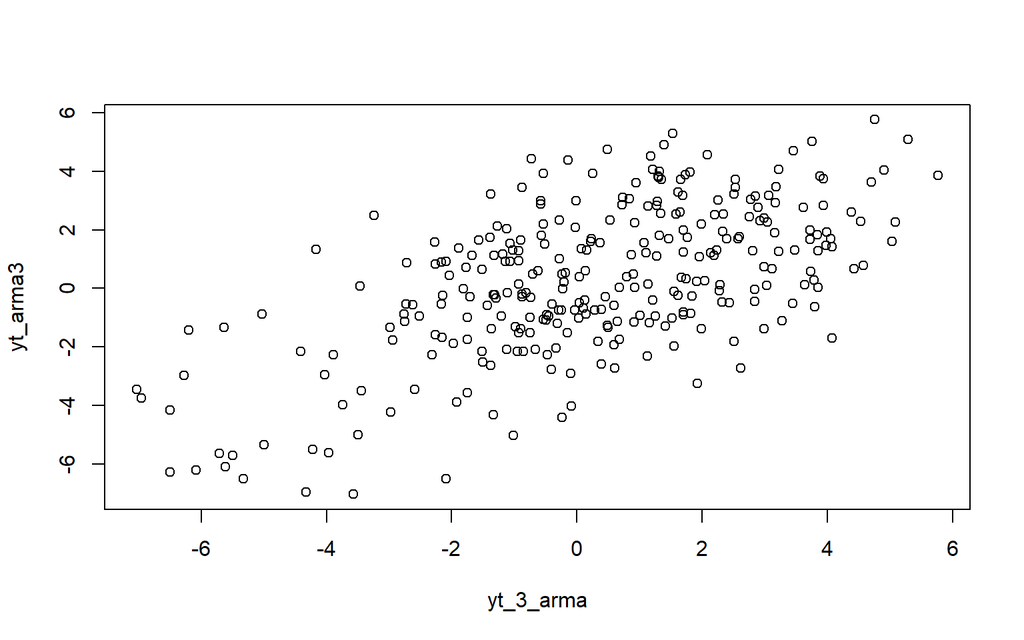

```r
plot(y=yt_arma3,x=yt_3_arma)
```

Berdasarkan scatterplot tersebut, terlihat bahwa terdapat hubungan positif antara $Y_t$ dengan $Y_{t-3}$. Hal ini sesuai dengan teori yang ada

```r
cor(yt_arma3,yt_3_arma)
```

```
## [1] 0.6044325
```

Korelasi antara $Y_t$ dengan $Y_{t-3}$ dari hasil simulasi mendekati perhitungan teoritis.
$$\rho_3=\phi_1 \rho_2 + \phi_2 \rho_1 = (0,5)(0,78) + (0,2)(0,89) = 0.568$$